# Mini-Project 1 Regression

Aaron

June 2, 2016

```r
library(DAAG)
library(dplyr)
library(readr)
library(knitr)
library(magrittr)
```

### Synopsis

#### What study will achieve?

In this assignment, I useed the R dataset `“litters”` (from the `DAAG` package) and create a regression model to predict brain weight.

#### Cite the data source

Data Description From DAAG Document

> Data on the body and brain weights of 20 mice, together with the size of the litter. Two mice were taken from each litter size.

> Wainright P, Pelkman C and Wahlsten D 1989. The quantitative relationship between nutritional effects on preweaning growth and behavioral development in mice. Developmental Psychobiology 22: 183-193.

### Methods

#### Why (statistically) you can use the technique you choose?

I choose `regression` because it helps to fit a linear pattern through data.

#### Explain the fields in the dataset

```r
glimpse(litters)
```

```
## Observations: 20
## Variables: 3
## $ lsize   (dbl) 3, 3, 4, 4, 5, 5, 6, 6, 7, 7, 8, 8, 9, 9, 10, 10, 11, ...
## $ bodywt  (dbl) 9.447, 9.780, 9.155, 9.613, 8.850, 9.610, 8.298, 8.543...
## $ brainwt (dbl) 0.444, 0.436, 0.417, 0.429, 0.425, 0.434, 0.404, 0.439...
```

- `lsize`: litter size
- `bodywt`: body weight
- `brainwt`: brain weight

#### Explain/show your experimental setup (i.e. the r linear model)

As follow:

```r
litters %>%
        lm(brainwt ~ lsize + bodywt, .) %>% summary()
```

```
##
## Call:
## lm(formula = brainwt ~ lsize + bodywt, data = .)
##
## Residuals:
##        Min         1Q     Median         3Q        Max
## -0.0230005 -0.0098821  0.0004512  0.0092036  0.0180760
##
## Coefficients:
##             Estimate Std. Error t value Pr(>|t|)
## (Intercept) 0.178247   0.075323   2.366  0.03010 *
## lsize       0.006690   0.003132   2.136  0.04751 *
## bodywt      0.024306   0.006779   3.586  0.00228 **
## ---
## Signif. codes:  0 '***' 0.001 '**' 0.01 '*' 0.05 '.' 0.1 ' ' 1
##
## Residual standard error: 0.01195 on 17 degrees of freedom
## Multiple R-squared:  0.6505, Adjusted R-squared:  0.6094
## F-statistic: 15.82 on 2 and 17 DF,  p-value: 0.0001315
```

### Analysis

#### Show your final regression equation:

```r
litters %>% lm(brainwt ~ lsize + bodywt, .) -> fit_0

as.formula(
  paste0("brainwt ~ ", round(coefficients(fit_0)[1],4), " + ",
    paste(sprintf("%.4f * %s",
                  coefficients(fit_0)[-1],
                  names(coefficients(fit_0)[-1])),
          collapse=" + ")
  )
)
```

```
## brainwt ~ 0.1782 + 0.0067 * lsize + 0.0243 * bodywt
```

#### Show a diagram of your regression model vs. the data

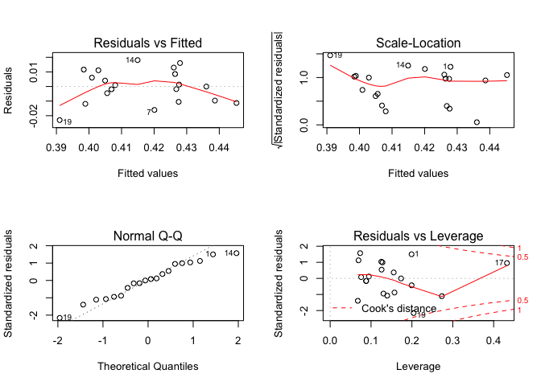

```r
layout(matrix(c(1,2,3,4),2,2)) # optional 4 graphs/page
plot(fit_0)
```

#### Discuss the quality of fit, explain what the diagram shows in terms of how to use it to predict

From the summary, quality of the fit is good, model explain **60.94%** variation of the data.

We use the final equation to get the expected value of the **brain weight** by inputting the right `lsize` and `bodywt`